# Tarea 4: regresión logística

En esta tarea construiremos varios modelos de regresión logística y compararemos sus resultados.

### Preparación

Puedes usar el siguiente código, o tus implementaciones propias:

```r
source("tarea_4_codigo.R")
```

Revisa las funciones que están ahí. Son las que usamos en clase.

Usaremos los datos de sobrevivientes del hundimiento del Titanic, obtenidos de [este concurso de Kaggle](https://www.kaggle.com/c/titanic)

```r
library(tidyverse)
datos_titanic <- read_csv("./tarea_4_datos/train.csv")
```

En este caso, queremos predecir la variable *Survived* en términos del resto. Para simiplificar el ejericicio,

- solo usaremos algunas de las variables,
- ignoramos datos faltantes en la variable edad

```r
datos_titanic <- datos_titanic %>% select(Survived, Pclass, Age, Sex, Embarked) %>%
    filter(!is.na(Age), !is.na(Embarked))
summary(datos_titanic)
```

```
    Survived          Pclass          Age            Sex
 Min.   :0.0000   Min.   :1.00   Min.   : 0.42   Length:712
 1st Qu.:0.0000   1st Qu.:1.00   1st Qu.:20.00   Class :character
 Median :0.0000   Median :2.00   Median :28.00   Mode  :character
 Mean   :0.4045   Mean   :2.24   Mean   :29.64
 3rd Qu.:1.0000   3rd Qu.:3.00   3rd Qu.:38.00
 Max.   :1.0000   Max.   :3.00   Max.   :80.00
   Embarked
 Length:712
 Class :character
 Mode  :character
```

```r
head(datos_titanic)
```

| Survived | Pclass | Age | Sex | Embarked |
| --- | --- | --- | --- | --- |
| 0 | 3 | 22 | male | S |
| 1 | 1 | 38 | female | C |
| 1 | 3 | 26 | female | S |
| 1 | 1 | 35 | female | S |
| 0 | 3 | 35 | male | S |
| 0 | 1 | 54 | male | S |

La descripción de las variables es:

survival Survival 0 = No, 1 = Yes pclass Ticket class 1 = 1st, 2 = 2nd, 3 = 3rd sex Sex Age Age in years  
embarked Port of Embarkation C = Cherbourg, Q = Queenstown, S = Southampton

Convertimos las variables categóricas a numerícas creando indicadoras, como sigue:

```r
datos <- datos_titanic %>%
         mutate(female = as.numeric(Sex == "female"),
                southampton = as.numeric(Embarked == "S"),
                cherbourg = as.numeric(Embarked == "C")) %>%
        select(-Embarked, -Sex)
datos
```

| Survived | Pclass | Age | female | southampton | cherbourg |
| --- | --- | --- | --- | --- | --- |
| 0 | 3 | 22.00 | 0 | 1 | 0 |
| 1 | 1 | 38.00 | 1 | 0 | 1 |
| 1 | 3 | 26.00 | 1 | 1 | 0 |
| 1 | 1 | 35.00 | 1 | 1 | 0 |
| 0 | 3 | 35.00 | 0 | 1 | 0 |
| 0 | 1 | 54.00 | 0 | 1 | 0 |
| 0 | 3 | 2.00 | 0 | 1 | 0 |
| 1 | 3 | 27.00 | 1 | 1 | 0 |
| 1 | 2 | 14.00 | 1 | 0 | 1 |
| 1 | 3 | 4.00 | 1 | 1 | 0 |

[output cut: 702 more lines]

Consierando cómo se ven estos datos, podemos usar una normalización simple (puedes también hacerlo como lo hicimos en clase), de forma que todas las variables estén aproximadamente en el rango 0 - 1 :

```r
datos$age_n <- datos$Age / 60
datos$pclass_n <-(datos$Pclass - 1) / 3
datos_trans <- datos %>% select(Survived, pclass_n, age_n, female, southampton, cherbourg)
datos_trans
```

| Survived | pclass_n | age_n | female | southampton | cherbourg |
| --- | --- | --- | --- | --- | --- |
| 0 | 0.6666667 | 0.36666667 | 0 | 1 | 0 |
| 1 | 0.0000000 | 0.63333333 | 1 | 0 | 1 |
| 1 | 0.6666667 | 0.43333333 | 1 | 1 | 0 |
| 1 | 0.0000000 | 0.58333333 | 1 | 1 | 0 |
| 0 | 0.6666667 | 0.58333333 | 0 | 1 | 0 |
| 0 | 0.0000000 | 0.90000000 | 0 | 1 | 0 |
| 0 | 0.6666667 | 0.03333333 | 0 | 1 | 0 |
| 1 | 0.6666667 | 0.45000000 | 1 | 1 | 0 |
| 1 | 0.3333333 | 0.23333333 | 1 | 0 | 1 |
| 1 | 0.6666667 | 0.06666667 | 1 | 1 | 0 |

[output cut: 702 more lines]

Y finalmente, separa en entrenamiento y prueba de esta forma (como estamos normalizando con cantidades fijas, no tenemos que normalizar por separado):

```r
set.seed(2850)
datos_trans <- datos_trans %>%
    mutate(u = runif(nrow(datos_trans)))
entrena <- datos_trans %>% filter(u <= 0.7) %>% select(-u)
prueba <- datos_trans %>% filter(u > 0.7) %>% select(-u)
```

```r
nrow(entrena)
```

```
[1] 512
```

```r
nrow(prueba)
```

```
[1] 200
```

```r
x_ent <- as.matrix(entrena %>% select(-Survived))
x_pr <- as.matrix(prueba %>% select(-Survived))
y_ent <- entrena$Survived
y_pr <- prueba$Survived
```

### Ejercicio A

1. Ajusta un modelo usando solo una variable (por ejemplo, el indicador si abordó en cherbourg). Ajusta el tamaño de paso y checa convergencia

```r
x_ent_1 <- x_ent[ , "cherbourg", drop = FALSE] # drop=false es para no convertir en vector
devianza_ent <- devianza_calc(x_ent_1, y_ent)
grad_ent <- grad_calc(x_ent_1, y_ent)
## termina esta línea para descenso en gradiente
z <- descenso(130,c(-0.2,0.2),0.005,grad_ent)
tail(z)
```

```
             [,1]     [,2]
[125,] -0.5968161 1.140432
[126,] -0.5968161 1.140432
[127,] -0.5968161 1.140432
[128,] -0.5968161 1.140432
[129,] -0.5968161 1.140432
[130,] -0.5968161 1.140432
```

```r
#grad_ent(0.2)
glm(Survived ~ cherbourg, data = entrena, family = "binomial" )
```

```
Call:  glm(formula = Survived ~ cherbourg, family = "binomial", data = entrena)

Coefficients:
(Intercept)    cherbourg
    -0.5968       1.1404

Degrees of Freedom: 511 Total (i.e. Null);  510 Residual
Null Deviance:      692.4
Residual Deviance: 667.5    AIC: 671.5
```

2. Calcula ahora la devianza de prueba de este modelo

```r
x_pr_1 <-  x_pr[ , "cherbourg", drop = FALSE]
devianza_pr <- devianza_calc(x_pr_1, y_pr)
# termina esta línea
devianza_ent(z[130,]) ## 667.5147 -- devianza de entrenamiento
```

```
[1] 667.5147
```

```r
devianza_ent(z[130,])/nrow(x_ent) ## 1.30374
```

```
[1] 1.30374
```

```r
devianza_pr(z[130,]) ## 266.9904 -- devianza de prueba
```

```
[1] 266.9904
```

```r
devianza_pr(z[130,])/nrow(x_pr) ## 1.334952
```

```
[1] 1.334952
```

3. Para este modelo simple, calcula la probabilidad estimada por el modelo de sobrevivir para una persona que embarcó en cherbourg y una que no:

```r
# Rellena:
# probabilidad sobrevivir si no embarcó en Cherbourg
p_beta(0,z[130,])
```

```
          [,1]
[1,] 0.3550725
```

```r
# probabilidad si embarcó  en Cherbourg
p_beta(1,z[130,])
```

```
          [,1]
[1,] 0.6326531
```

4. Curva ROC

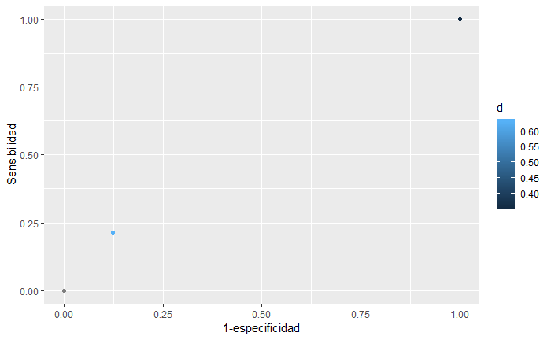

```r
library(ROCR)
mod_1 <- glm(Survived ~ cherbourg, entrena, family = "binomial")
#mod_1
prueba$probs_prueba_1 <- predict(mod_1, newdata = prueba, type = "response")
#tail(x_pr)
pred_rocr <- prediction(prueba$probs_prueba_1, prueba$Survived)
perf <- performance(pred_rocr, measure = "sens", x.measure = "fpr")
graf_roc_1 <- data_frame(tfp = perf@x.values[[1]], sens = perf@y.values[[1]],
                       d = perf@alpha.values[[1]])
ggplot(graf_roc_1, aes(x = tfp, y = sens, colour=d)) + geom_point() +
  xlab('1-especificidad') + ylab('Sensibilidad')
```

```r
auc_1 <- performance(pred_rocr, measure = 'auc')@y.values
auc_1 #0.5456115
```

```
[[1]]
[1] 0.5456115
```

### Ejercicio B

Ahora utiliza todas las variables, y repite el ejercicio anterior:

```r
devianza_ent <- devianza_calc(x_ent, y_ent)
grad_ent <- grad_calc(x_ent, y_ent)
## termina esta línea
z <- descenso(500,c(0.2,-2,-1,0.2,0.2,0.2),0.003,grad_ent)
colnames(z) <- colnames(entrena)
tail(z)
```

```
        Survived  pclass_n     age_n   female southampton cherbourg
[495,] 0.4014589 -3.293791 -1.854951 2.344978   0.4875305 0.9278126
[496,] 0.4014056 -3.293789 -1.854954 2.344980   0.4875836 0.9278689
[497,] 0.4013526 -3.293786 -1.854957 2.344983   0.4876365 0.9279247
[498,] 0.4012997 -3.293783 -1.854959 2.344986   0.4876890 0.9279803
[499,] 0.4012470 -3.293780 -1.854961 2.344988   0.4877412 0.9280356
[500,] 0.4011946 -3.293777 -1.854963 2.344991   0.4877931 0.9280906
```

```r
#matplot(z)
```

2. Calcula ahora la devianza de prueba de este modelo

```r
devianza_pr <- devianza_calc(x_pr, y_pr)
devianza_pr(z[500,] ) ## 155.7327 -- devianza de prueba (6 variables)
```

```
[1] 155.7327
```

```r
devianza_pr(z[500,])/nrow(x_pr) ## 0.7786637 (6 variables)
```

```
[1] 0.7786637
```

```r
devianza_ent(z[500,]) ## 488.6215 -- devianza entrenamiento (6 variables)
```

```
[1] 488.6215
```

```r
devianza_ent(z[500,])/nrow(x_ent) ## 0.9543389 --devianza entrenamiento (6 variables)
```

```
[1] 0.9543389
```

3. Calcula la probabidad estimada de que un hombre con boleto de 3a clase, de 60 años, que abordó en southampton sobreviva. Repite para una mujer con boleto de 1a clase, de 60 años, que abordó en southampton

```r
x_h_1 <- cbind(0,1,0,1,0)
x_h_2 <- cbind(1/3,1,0,1,0)
x_h_3 <- cbind(2/3,1,0,1,0)
x_m <- cbind(0,1,1,1,0)
p_beta(x_h_1,z[500,])
```

```
          [,1]
[1,] 0.2756834
```

```r
p_beta(x_h_2,z[500,])
```

```
          [,1]
[1,] 0.1126552
```

```r
p_beta(x_h_3,z[500,])
```

```
           [,1]
[1,] 0.04062778
```

```r
p_beta(x_m,z[500,])
```

```
          [,1]
[1,] 0.7988328
```

4. Grafica las probabilidades estimadas para alguien que subió en Southampton, para todos los rangos de edad, hombres y mujeres, de las tres clases posibles. Puedes empezar con el siguiente código:

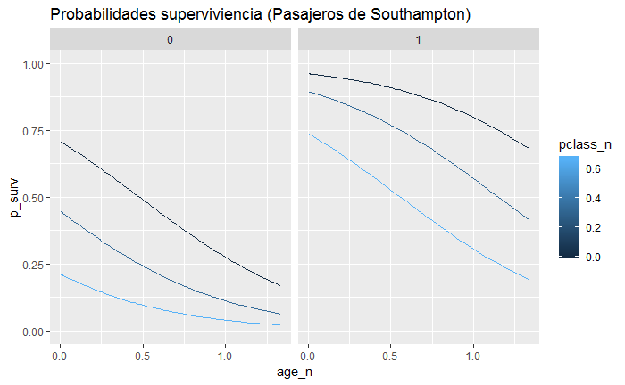

```r
# vamos a calcular proabilidades para estos datos
dat_calc <- expand.grid(list ( pclass_n = unique(x_ent[,"pclass_n"]),
                   age_n = unique(x_ent[, "age_n"]),
                   female = c(0,1),
                   southampton = 1,
                   cherbourg = 0))
mat_calc <- as.matrix(dat_calc)
## rellena aquí las betas que obtuviste
beta <- z[500,]
# calcula las probabilidades (puedes usar la fucnión p_beta, por ejemplo)
dat_calc$p_surv <- p_beta(mat_calc,beta)
ggplot(dat_calc, aes(x = age_n, y = p_surv, colour= pclass_n, group=pclass_n)) +
    facet_wrap(~female) + geom_line() + ylim(c(0, 1)) +
    labs(title = "Probabilidades superviviencia (Pasajeros de Southampton)")
```

¿Cuáles son las probabilidades más altas? ¿Cuáles son las más bajas? # Las probabilidades de supervivencia más altas corresponden a mujeres de primera clase

5. ¿Cuál de los dos modelos anteriores (una sola variable, todas las variables) se desempeña mejor? ¿Por qué? # Varias variables, la devianza es menor
6. Calcula el error de clasificación de prueba

```r
#p_beta(x_pr,z[500,])
prueba$p_est <- p_beta(x_pr,z[500,])
prueba <- prueba %>%
          mutate(Survived_est = ifelse(prueba$p_est <= 0.5,0,1))
prueba <- prueba %>%
          mutate(err_clas = ifelse(prueba$Survived == prueba$Survived_est,0,1))
mean(prueba$err_clas)
```

```
[1] 0.175
```

7. Curva ROC

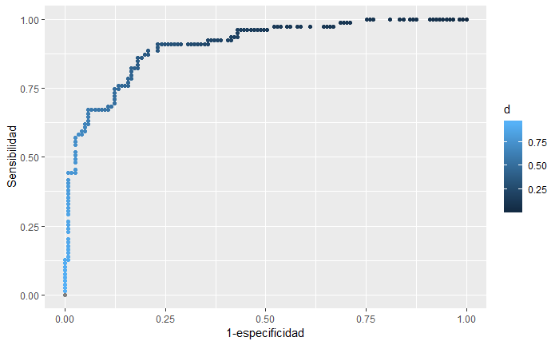

```r
library(ROCR)
mod_2 <- glm(Survived ~ pclass_n + age_n +female + southampton + cherbourg, entrena,
             family = "binomial")
prueba$probs_prueba_2 <- predict(mod_2, newdata = prueba, type = "response")
pred_rocr_2 <- prediction(prueba$probs_prueba_2, prueba$Survived)
perf_2 <- performance(pred_rocr_2, measure = "sens", x.measure = "fpr")
graf_roc_2 <- data_frame(tfp = perf_2@x.values[[1]], sens = perf_2@y.values[[1]],
                       d = perf_2@alpha.values[[1]])
ggplot(graf_roc_2, aes(x = tfp, y = sens, colour=d)) + geom_point() +
  xlab('1-especificidad') + ylab('Sensibilidad')
```

```r
auc_2 <- performance(pred_rocr_2, measure = 'auc')@y.values
auc_2 #0.9053248
```

```
[[1]]
[1] 0.9053248
```

### Ejercicio C

Ahora supondremos que tenemos algunas variables adicionales para incluir en el modelo. En este ejercicio veremos qué sucede si estas variables **no** pueden ayudarnos a predecir (las simulamos al azar)

Dada la escala de nuestras variables, podemos simular variables con valores entre 0 y 1

```r
set.seed(201)
p_ruido <- 50 # agregamos 50 variables sin información
n_ent <- nrow(x_ent)
n_pr <- nrow(x_pr)
mat_ent <- matrix(runif(n_ent * p_ruido), n_ent, p_ruido)
mat_pr <- matrix(runif(n_pr * p_ruido), n_pr, p_ruido)
#head(mat_ent)
```

1. Ajusta un modelo usando todas las variables, incluyendo las generadas aleatoriamente:

```r
devianza_ent <- devianza_calc(cbind(x_ent, mat_ent), y_ent)
grad_ent <- grad_calc(cbind(x_ent, mat_ent), y_ent)
## termina esta línea
set.seed(300)
z_ini <- c(0,-2,-2,1,2,0.2,runif(50,0,1))
z <- descenso(600,z_ini,0.0001,grad_ent)
tail(z)
```

```
             [,1]      [,2]      [,3]     [,4]      [,5]      [,6]       [,7]
[595,] -0.8741483 -2.936350 -2.081081 2.178005 0.4247107 0.9491714 0.07337700
[596,] -0.8739546 -2.936737 -2.080659 2.178566 0.4246973 0.9494986 0.07293217
[597,] -0.8737609 -2.937124 -2.080237 2.179126 0.4246847 0.9498251 0.07248779
[598,] -0.8735673 -2.937511 -2.079817 2.179684 0.4246729 0.9501508 0.07204386
[599,] -0.8733737 -2.937897 -2.079397 2.180239 0.4246619 0.9504757 0.07160038
[600,] -0.8731802 -2.938282 -2.078977 2.180794 0.4246517 0.9507999 0.07115735
            [,8]       [,9]     [,10]      [,11]      [,12]     [,13]       [,14]
[595,] 0.3988406 0.02481357 0.1707199 0.02755933 0.03240026 0.3359015 -0.06718348
[596,] 0.3990465 0.02443814 0.1706102 0.02741281 0.03299590 0.3358866 -0.06724941
[597,] 0.3992523 0.02406298 0.1705004 0.02726645 0.03359085 0.3358716 -0.06731533
[598,] 0.3994579 0.02368809 0.1703906 0.02712024 0.03418511 0.3358565 -0.06738123
[599,] 0.3996633 0.02331348 0.1702807 0.02697419 0.03477870 0.3358412 -0.06744711
[600,] 0.3998686 0.02293915 0.1701708 0.02682828 0.03537160 0.3358258 -0.06751298
            [,15]      [,16]     [,17]      [,18]      [,19]        [,20]     [,21]
```

[output cut: 41 more lines]

2. Calcula ahora la devianza de prueba de este modelo

```r
devianza_pr <- devianza_calc(cbind(x_pr, mat_pr), y_pr)
devianza_pr(z[600,]) ##165.3291
```

```
[1] 165.3291
```

```r
devianza_pr(z[600,])/nrow(x_pr) ##0.8266454 (50 variables) vs ## 0.7786637 (6 variables)
```

```
[1] 0.8266454
```

```r
devianza_ent(z[600,]) ## 461.8003
```

```
[1] 461.8003
```

```r
devianza_ent(z[600,])/nrow(x_ent) ## 0.9019537
```

```
[1] 0.9019537
```

```r
devianza_ent(z[600,]) # 461.8003 -- 50 variables ruidosas
```

```
[1] 461.8003
```

```r
devianza_ent(z[600,])/nrow(x_ent) ## 0.9019537 -- 50 variables ruidosas
```

```
[1] 0.9019537
```

```r
## 0.9543389 --devianza entrenamiento (6 variables)
```